# Clark-Izzi-ADA-homework-2

Challenge 1:

Filter dataset, add decade column, plot runtimeMinutes histogram for each decade.

```r
f <- "https://raw.githubusercontent.com/difiore/ADA-datasets/master/IMDB-movies.csv"
d <- read_csv(f, col_names = TRUE)
```

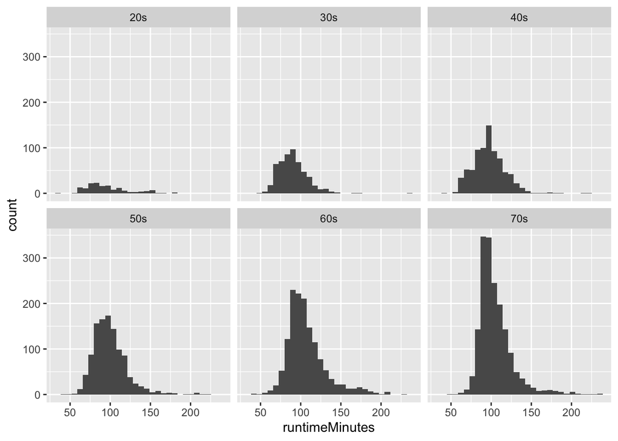

```r
s <- filter(d, startYear >= 1920 & startYear <= 1979 & runtimeMinutes < 240)
s <- mutate(s, "decade" = paste(substr(startYear,3,3), "0s", sep = ""))
p <- ggplot(s, aes(x=runtimeMinutes), color = factor(decade)) + geom_histogram() + facet_wrap(~decade, ncol = 3) # wrap data by decade into 3 columns
p
```

```r
results <- s %>% group_by(decade) %>%
  summarise(
    popMean = mean(runtimeMinutes, na.rm = TRUE),
    popSD = sd(runtimeMinutes, na.rm = TRUE),
  )
results
```

```
## # A tibble: 6 x 3
##   decade popMean popSD
##   <chr>    <dbl> <dbl>
## 1 20s       96.0  27.5
## 2 30s       90.2  18.7
## 3 40s       97.3  20.6
## 4 50s       99.6  21.6
## 5 60s      107.   24.3
## 6 70s      105.   21.4
```

Single sample of 100 movies from each decade: sample mean and standard deviation, plus estimate of SE around population mean

```r
results_samp <- tibble(decade = character(), sampMean = numeric(), sampSD = numeric(), estSE = numeric())
for (d in unique(s$decade)){
  samp <- sample_n(filter(s, decade == d), size = 100, replace = FALSE)
  x <- mean(samp$runtimeMinutes, na.rm = TRUE)
  y <- sd(samp$runtimeMinutes, na.rm = TRUE)
  z <- y / sqrt(100) # estimate pop SE from SD of sample
  results_samp <- add_row(results_samp, decade = d, sampMean = x, sampSD = y, estSE = z)
}
results_samp
```

```
## # A tibble: 6 x 4
##   decade sampMean sampSD estSE
##   <chr>     <dbl>  <dbl> <dbl>
## 1 20s        97.0   27.0  2.70
## 2 30s        89.7   17.5  1.75
## 3 40s        98.5   18.3  1.83
## 4 50s        96     18.5  1.85
## 5 60s       109.    27.5  2.75
## 6 70s       104.    22.9  2.29
```

Compare estimates to actual population mean and calculated SE based on population standard deviation. (I added to the population results table from earlier.) Slightly different but comparable to sample stats!

```r
results <- mutate(results, "calcSE" = popSD/sqrt(100)) # expected SE for sample size of 100
results
```

```
## # A tibble: 6 x 4
##   decade popMean popSD calcSE
##   <chr>    <dbl> <dbl>  <dbl>
## 1 20s       96.0  27.5   2.75
## 2 30s       90.2  18.7   1.87
## 3 40s       97.3  20.6   2.06
## 4 50s       99.6  21.6   2.16
## 5 60s      107.   24.3   2.43
## 6 70s      105.   21.4   2.14
```

Sampling distribution of mean runtimeMinutesfor each decade. Had trouble actually getting them to print from inside the loop - maybe my computer is too slow? Commented it out for now.

Challenge 2:

What is the probability that she will hear 13 or fewer calls during any given session? 0.1425978

```r
l = 18
ppois(q = 13, lambda = l)
```

```
## [1] 0.1425978
```

What is the probability that she will hear no calls in a session? 1.522998e-08

```r
dpois(x = 0, lambda = l)
```

```
## [1] 1.522998e-08
```

What is the probability that she will hear exactly 7 calls in a session? 0.00185002

```r
dpois(x = 7, lambda = l)
```

```
## [1] 0.00185002
```

What is the probability that she will hear more than 20 calls in a session? (1-ppois?) 0.2692798

```r
1-ppois(q = 20, lambda = l)
```

```
## [1] 0.2692798
```

Plot the relevant Poisson mass function over the values in range 0 ≤ x ≤ 40.

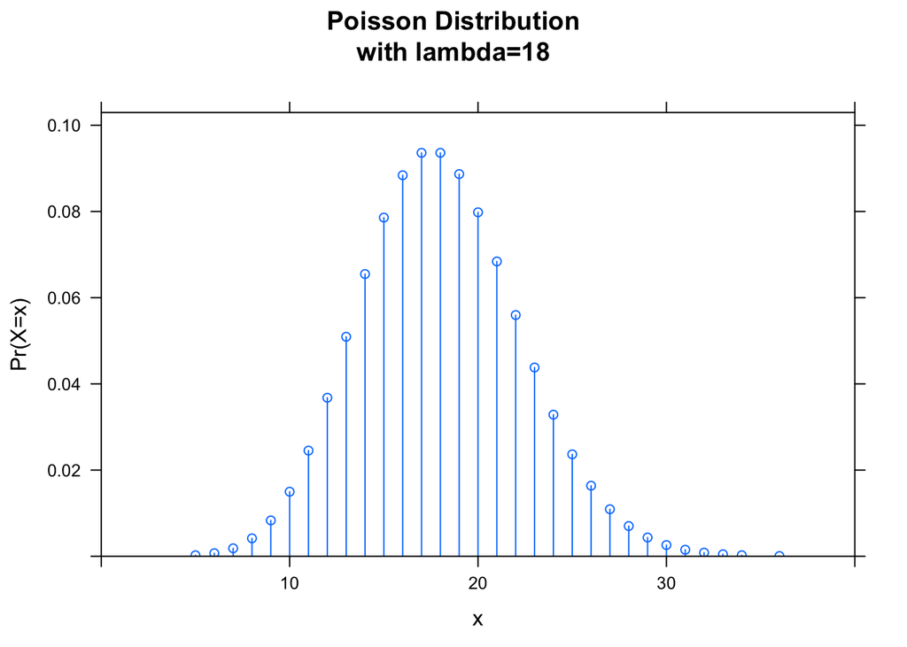

```r
p <- plotDist(
  "pois",
  lambda = l,
  xlim = c(0, 40),
  main = paste0("Poisson Distribution\nwith lambda=", l), xlab = "x",
  ylab = "Pr(X=x)"
)
p
```

Using the rpois() function, simulate 520 results from this distribution (i.e., 10 full years of Saturday monitoring sessions).

```r
pois_dist <- rpois(n = 520, lambda = l)
```

Plot the simulated results. How do your simulated results compare to the shape of the probability mass function you plotted above? 520 may not be a large enough sample (running a few times generated variable results), but overall similar to the probability mass function with a peak density around 18.

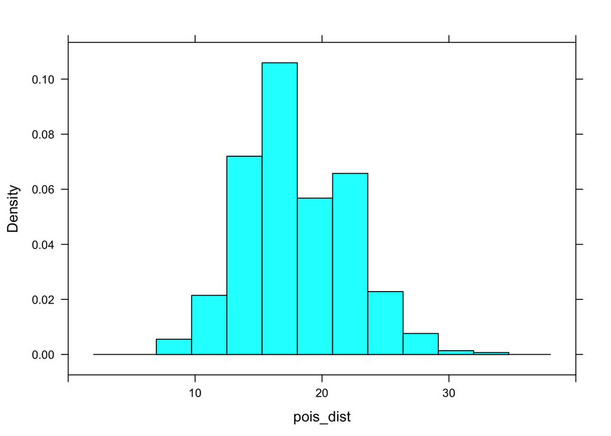

```r
histogram(pois_dist,
  xlim = c(0,40)
)
```

Challenge 3:

```r
f2 <- "https://raw.githubusercontent.com/difiore/ADA-datasets/master/zombies.csv"
d <- read_csv(f2, col_names = TRUE)
```

```r
height_m <- mean(d$height)
height_sd <- sdpop(d$height)
weight_m <- mean(d$weight)
weight_sd <- sdpop(d$weight)
age_m <- mean(d$age)
age_sd <- sdpop(d$age)
zombies_m <- mean(d$zombies_killed)
zombies_sd <- sdpop(d$zombies_killed)
education_m <- mean(d$years_of_education)
education_sd <- mean(d$years_of_education)
```

Scatterplots of height and weight in relation to age. Both increase as age increases, with an especially clear positive relationship between height and age.

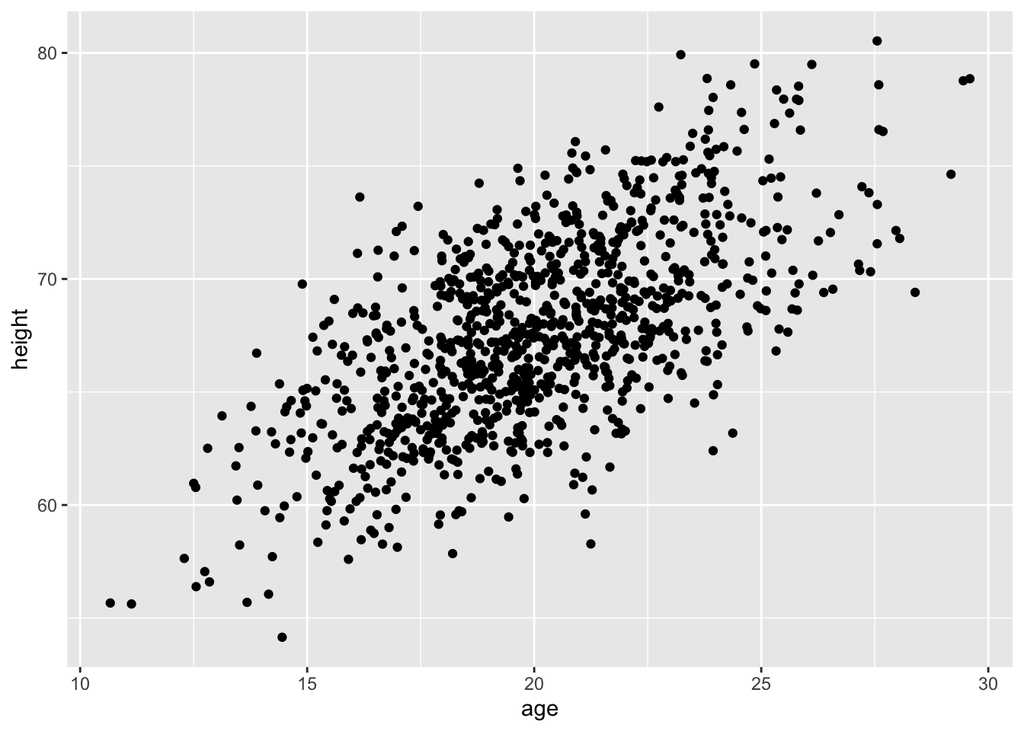

```r
p <- ggplot(data = d, aes(
  x = age,
  y = height,
))
p <- p + geom_point(na.rm = TRUE)
p
```

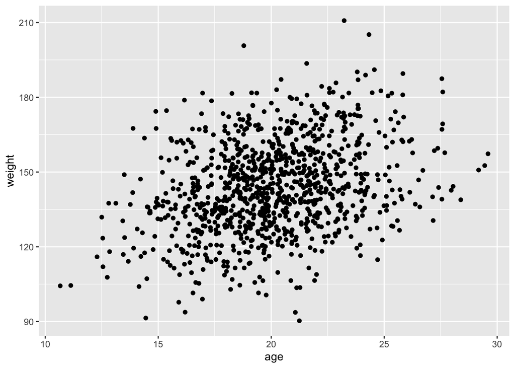

```r
p2 <- ggplot(data = d, aes(
  x = age,
  y = weight,
))
p2 <- p2 + geom_point(na.rm = TRUE)
p2
```

Histograms and Q-Q plots for each quantitative variable: Height, weight, and age are normally distributed. Distributions of zombies killed and years of education are slightly skewed (more people kill fewer zombies and have fewer years of education).

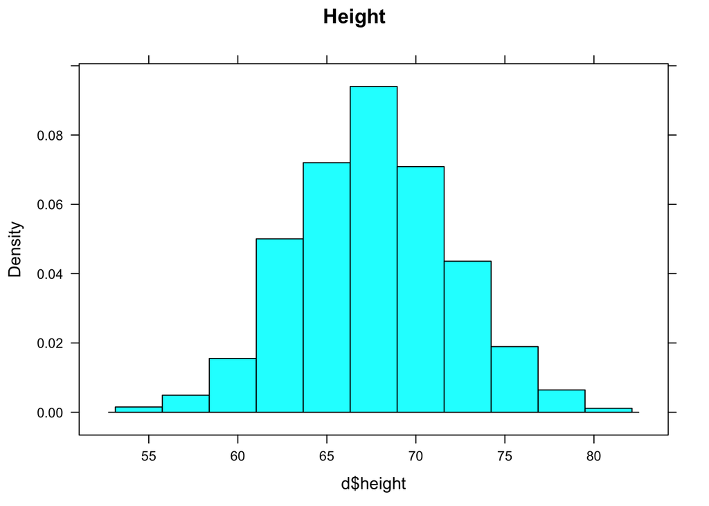

```r
histogram(d$height, center = height_m, main = "Height")
```

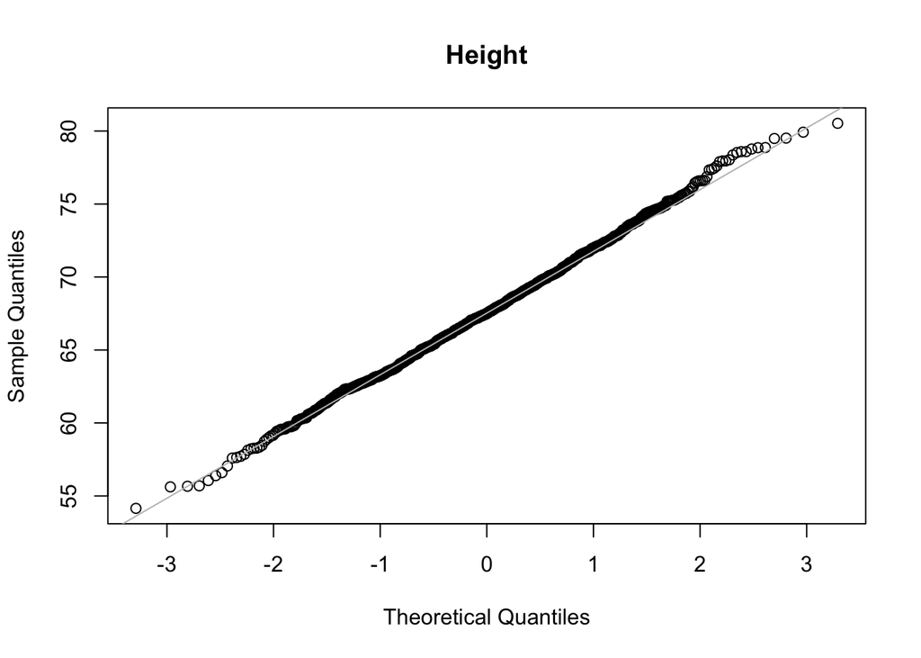

```r
qqnorm(d$height, main = "Height")
qqline(d$height, col = "gray")
```

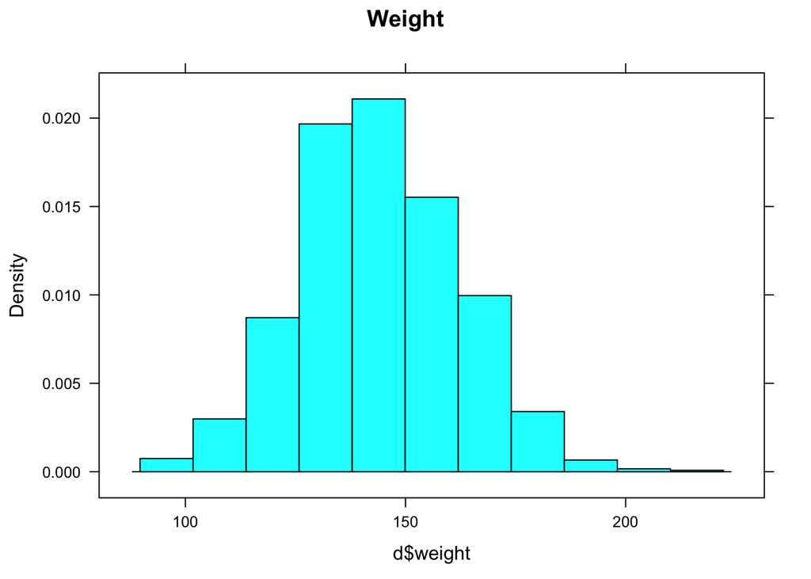

```r
histogram(d$weight, center = weight_m, main = "Weight")
```

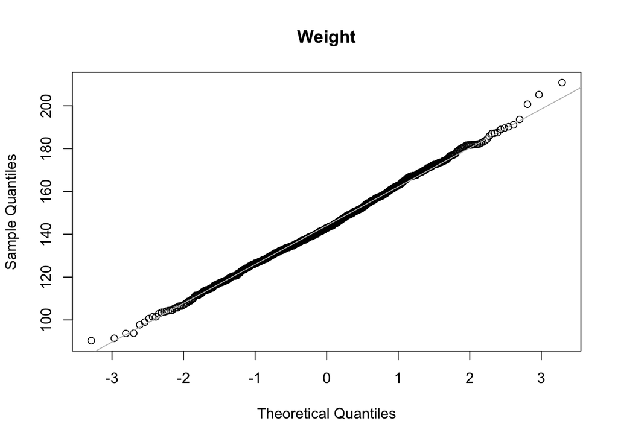

```r
qqnorm(d$weight, main = "Weight")
qqline(d$weight, col = "gray")
```

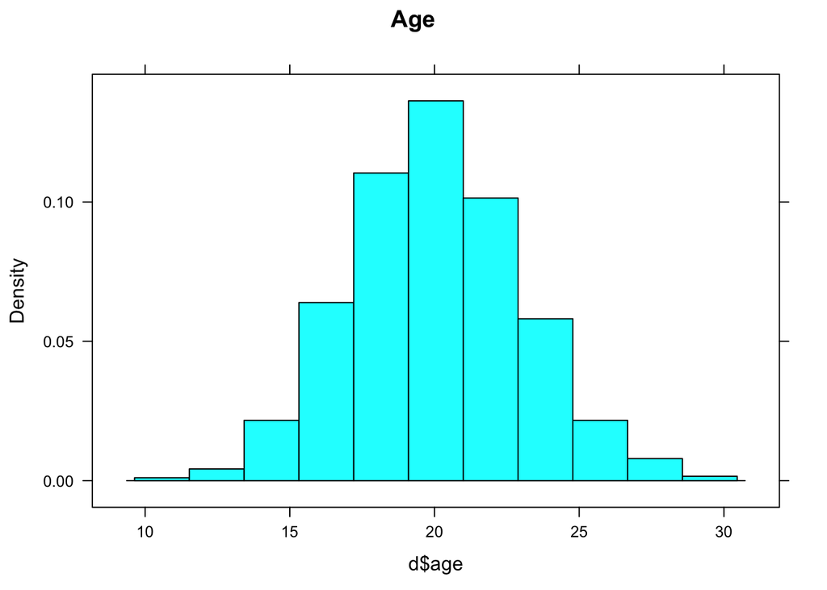

```r
histogram(d$age, center = age_m, main = "Age")
```

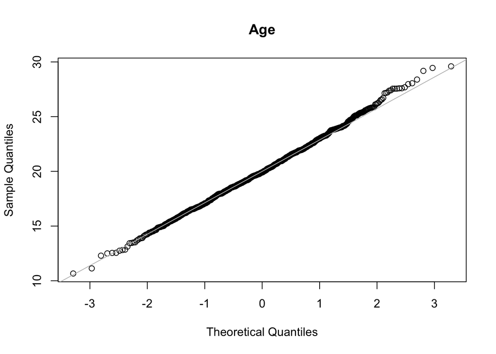

```r
qqnorm(d$age, main = "Age")
qqline(d$age, col = "gray")
```

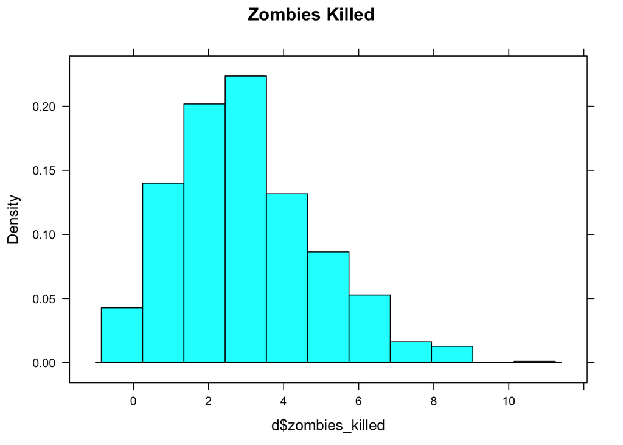

```r
histogram(d$zombies_killed, center = zombies_m, main = "Zombies Killed")
```

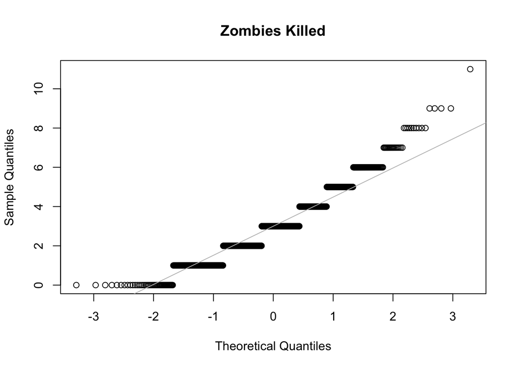

```r
qqnorm(d$zombies_killed, main = "Zombies Killed")
qqline(d$zombies_killed, col = "gray")
```

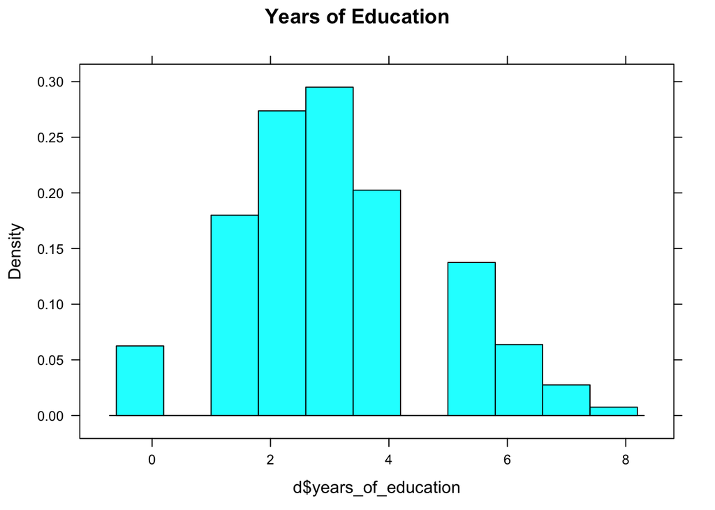

```r
histogram(d$years_of_education, center = education_m, main = "Years of Education")
```

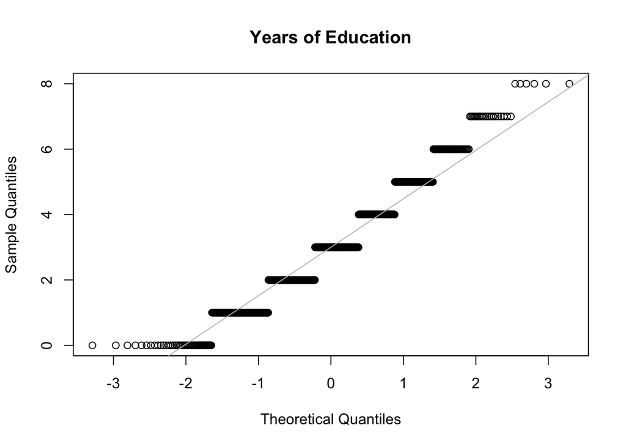

```r
qqnorm(d$years_of_education, main = "Years of Education")
qqline(d$years_of_education, col = "gray")
```

Sample 1 subset of 30 survivors.

```r
s <- sample_n(d, size = 30, replace = FALSE)
s <- select(s, height, weight, age, zombies_killed, years_of_education)
samp30 <- tibble(variable = character(), mean = numeric(), sd = numeric(), se = numeric(), ci_lower = numeric(), ci_upper = numeric())
for (i in seq_along(s)) {
  m <- mean(s[[i]])
  sd <- sd(s[[i]])
  se <- sd / sqrt(30)
  ci_L <- m - qnorm(1 - 0.05 / 2) * se
  ci_U <- m + qnorm(1 - 0.05 / 2) * se
  samp30 <- add_row(samp30, variable = (colnames(s)[i]), mean = m, sd = sd, se = se, ci_lower = ci_L, ci_upper = ci_U)
}
samp30
```

```
## # A tibble: 5 x 6
##   variable             mean    sd    se ci_lower ci_upper
##   <chr>               <dbl> <dbl> <dbl>    <dbl>    <dbl>
## 1 height              67.5   3.69 0.674    66.2     68.8
## 2 weight             143.   15.0  2.75    138.     149.
## 3 age                 20.2   3.46 0.632    18.9     21.4
## 4 zombies_killed       3.5   1.66 0.302     2.91     4.09
## 5 years_of_education   2.93  1.39 0.253     2.44     3.43
```

```r
set.seed(1)
height_dist <- do(99) * mean(~height, data = sample_n(d, size = 30, replace = FALSE))
weight_dist <- do(99) * mean(~weight, data = sample_n(d, size = 30, replace = FALSE))
age_dist <- do(99) * mean(~age, data = sample_n(d, size = 30, replace = FALSE))
zombies_dist <- do(99) * mean(~zombies_killed, data = sample_n(d, size = 30, replace = FALSE))
education_dist <- do(99) * mean(~years_of_education, data = sample_n(d, size = 30, replace = FALSE))
mean(~mean, data = height_dist)
```

```
## [1] 67.69637
```

```r
sd(~mean, data = height_dist)
```

```
## [1] 0.8009234
```

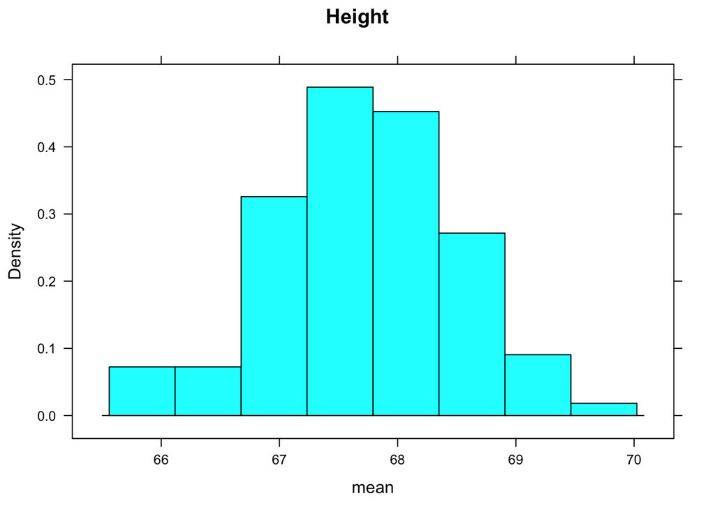

```r
histogram(~mean, data = height_dist, main = "Height")
```

```r
mean(~mean, data = weight_dist)
```

```
## [1] 143.5546
```

```r
sd(~mean, data = weight_dist)
```

```
## [1] 3.505573
```

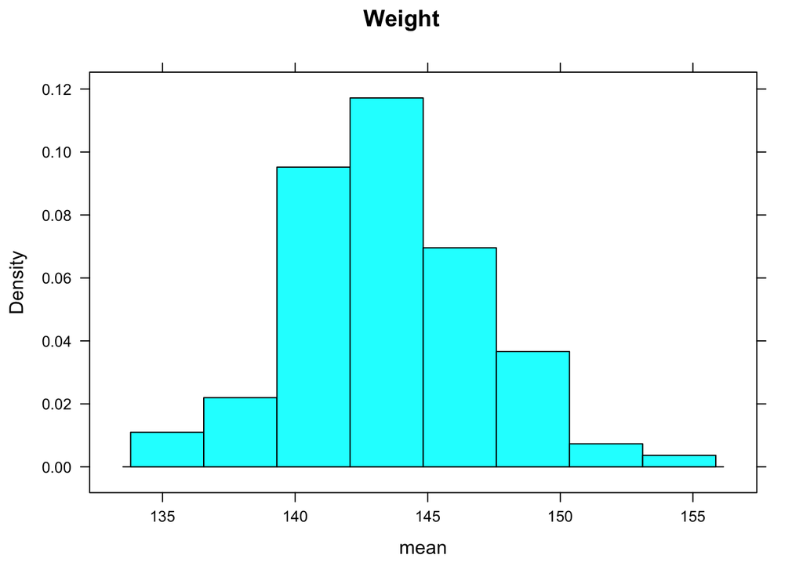

```r
histogram(~mean, data = weight_dist, main = "Weight")
```

```r
mean(~mean, data = age_dist)
```

```
## [1] 20.05219
```

```r
sd(~mean, data = age_dist)
```

```
## [1] 0.5684434
```

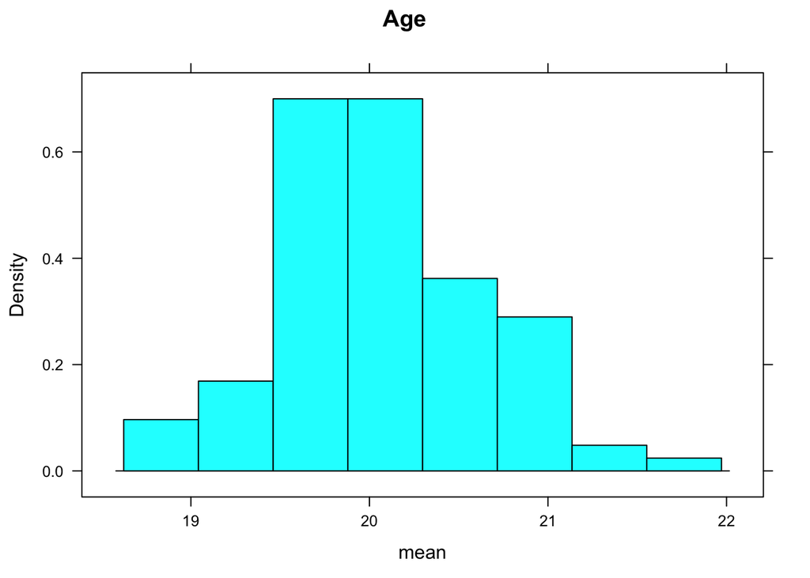

```r
histogram(~mean, data = age_dist, main = "Age")
```

```r
mean(~mean, data = zombies_dist)
```

```
## [1] 2.96936
```

```r
sd(~mean, data = zombies_dist)
```

```
## [1] 0.2948414
```

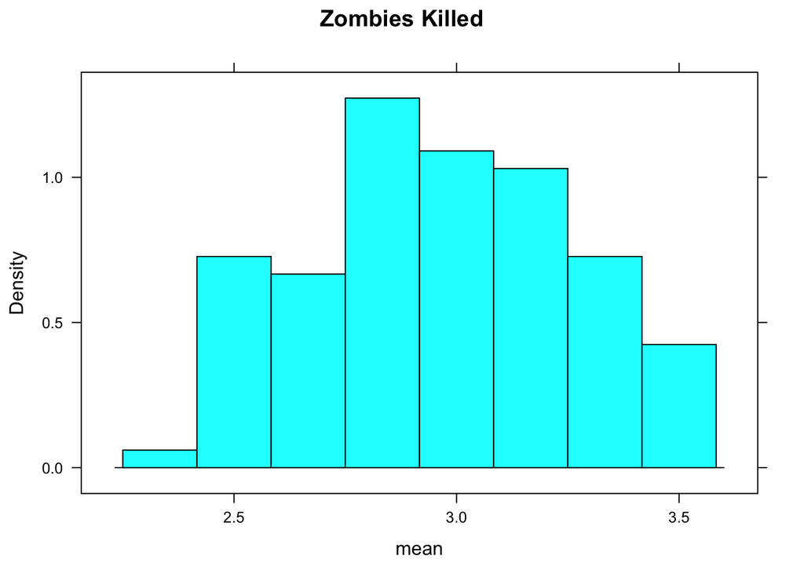

```r
histogram(~mean, data = zombies_dist, main = "Zombies Killed")
```

```r
mean(~mean, data = education_dist)
```

```
## [1] 2.989899
```

```r
sd(~mean, data = education_dist)
```

```
## [1] 0.2714893
```

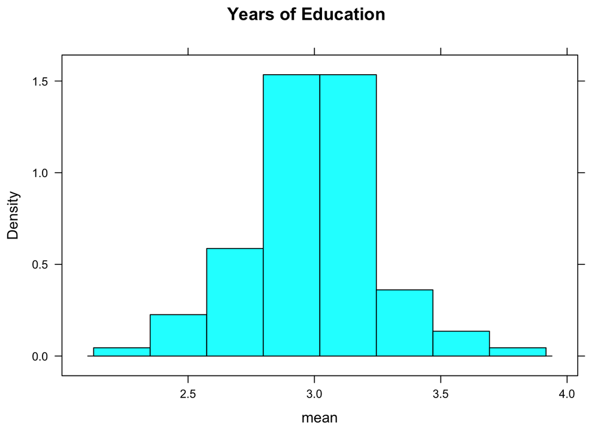

```r
histogram(~mean, data = education_dist, main = "Years of Education")
```